# visStatistics

Sabine Schilling

2025-05-18

# Overview

`visStatistics` allows for rapid visualisation and statistical analysis of raw data. It automatically selects and visualises the most appropriate hypothesis test between a response (`varsample`) and a feature (`varfactor`) within a `data.frame`. Its core function, `visstat()`, visualises this test with appropriate graphs (box plots, bar charts,regression lines with confidence bands, mosaic plots,residual plots, Q-Q plots), annotated with the main test results, including any assumption checks and post-hoc analyses. A minimal function call looks looks like:

```r
visstat(dataframe, varsample = "response", varfactor = "feature")
```

The input `data.frame` must be column-based, and the response `varsample` and feature `varfactor` must be character strings naming columns of the `data.frame`. The significance level $\alpha$, used throughout for hypothesis testing, is defined as `1 - conf.level`, where `conf.level` is a user-controllable argument (defaulting to `0.95`).

# 1 Overview of the decision logic

Data of class `"numeric"` or `"integer"` are referred to in the remainder as numerical, while data of class `"factor"` are referred to as categorical. The choice of statistical tests performed by the function `visstat()` depends on whether the data are numerical or categorical, the number of levels in the categorical variable, and the distribution of the data. The function prioritizes interpretable visual output and tests that remain valid under the the fowlloing decision logic:

## 1.1 Numerical response and categorical feature

When the response is numerical and the predictor is categorical, a statistical hypothesis test of central tendencies is selected.

### 1.1.1 Categorical predictor with two levels

If the categorical predictor has exactly two levels, Welch’s t-test (`t.test()`), is applied whenever both groups contain more than 30 observations, with the validity of the test supported by the approximate normality of the sampling distribution of the mean under the central limit theorem (Rasch, Kubinger, and Moder 2011; Lumley et al. 2002). For smaller samples, group-wise normality is assessed using the Shapiro-Wilk test (`shapiro.test()`) at the significance level $\alpha$. If both groups are found to be approximately normally distributed according to the Shapiro-Wilk test, Welch’s t-test is applied; otherwise, the Wilcoxon rank-sum test (`wilcox.test()`) is used.

### 1.1.2 Categorical predictor with more than two levels

For predictors with more than two levels, an ANOVA model (`aov()`) is initially fitted. The normality of residuals is evaluated using both the Shapiro–Wilk test (`shapiro.test()`) and the Anderson–Darling test (`ad.test()`); residuals are considered approximately normal if at least one of the two tests yields a result exceeding the significance threshold $\alpha$. If this condition is met, Bartlett’s test (`bartlett.test()`) is then used to assess homoscedasticity. When variances are homogeneous ($p > \alpha$), ANOVA is applied with Tukey’s HSD (`TukeyHSD()`) for post-hoc comparison. If variances differ significantly ($p \le \alpha$), Welch’s one-way test (`oneway.test()`) is used, also followed by Tukey’s HSD. If residuals are not normally distributed according to both tests ($p \le \alpha$), the Kruskal-Wallis test (`kruskal.test()`) is selected, followed by pairwise Wilcoxon tests (`pairwise.wilcox.test()`). A graphical overview of the decision logic used is provided in figure.

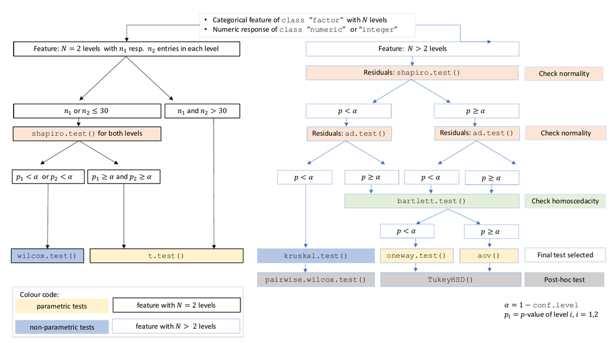

Decision tree used to select the appropriate statistical test for a categorical predictor and numerical response, based on the number of factor levels, normality and homoscedasticity.

## 1.2 Numerical response and numerical predictor

When both the response and predictor are numerical, a simple linear regression model (`lm()`) is fitted and analysed in detail, including residual diagnostics, formal tests, and the plotting of fitted values with confidence bands. Note that only one explanatory variable is allowed, as the function is designed for two-dimensional visualisation.

## 1.3 Categorical response and categorical predictor

In the case of two categorical variables, `visstat()` tests the null hypothesis that the predictor and response variables are independent using either `chisq.test()` or `fisher.test()`. The choice of test is based on Cochran’s rule (Cochran 1954), which advises that the $\chi^2$ approximation is reliable only if no expected cell count is zero and no more than 20 percent of cells have expected counts below 5.

Note: Except for the user-adjustable `conf.level` parameter, all statistical tests are applied using their default settings from the corresponding base R functions (e.g., `t.test()`). As a consequence, paired tests are not currently supported. Furthermore, since the main purpose of this package is to visualize statistical test results, only simple linear regression is implemented.

# 2 Decision logic for selecting tests of central tendency

If the feature consists of `class` “`factor`” with two or more levels and the response consists is of `class` “`numerical`” or “`integer`” (both having mode “`numerical`”), statistical tests are applied to compare the central tendencies across groups. This section describes the conditions under which parametric and non-parametric tests are chosen, based on the response type, the number of factor levels, and the underlying distributional assumptions.

## 2.1 Welch’s t-test and Wilcoxon rank sum test

When the feature variable has exactly two levels, Welch’s t-test or the Wilcoxon rank-sum test is applied.

Welch’s t-test assumes that the observations are independent and that the response variable is approximately normally distributed within each group. In contrast to Student’s t-test, it does not require the assumption of equal variances (homoscedasticity) between groups. Welch’s test remains valid and exhibits only minimal loss of efficiency even when the assumptions of Student’s t-test—namely, normality and equal variances of the response variable across groups—are satisfied (Moser and Stevens 1992; Delacre et al. 2017). Therefore, Student’s t-test is not implemented.

The Wilcoxon rank-sum test (`wilcox.test()`) is a non-parametric alternative that tests for a difference in location between two independent distributions.

The function selects between these tests as follows. If both groups contain more than 30 observations, Welch’s t-test (`t.test()`) is always applied, relying on the central limit theorem to justify its application regardless of underlying normality (Rasch, Kubinger, and Moder 2011; Lumley et al. 2002).

The graphical output consists of box plots overlaid with jittered points to display individual observations. When Welch’s t-test is applied, the function includes confidence intervals based on the user-specified `conf.level`. The function returns a list containing the results of the applied test and the summary statistics used to construct the plot.

### 2.1.1 Examples

#### Welch’s t-test

As an example, we use the *Motor Trend Car Road Tests* data set (`mtcars`), which contains 32 observations. In the example below, `mpg` denotes miles per (US) gallon, and `am` represents the transmission type (`0` = automatic, `1` = manual).

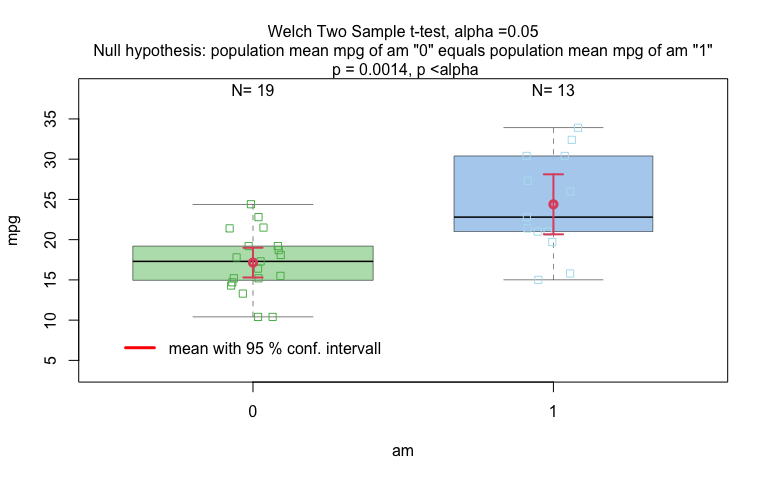

Increasing the confidence level `conf.level` from the default 0.95 to 0.99 results in wider confidence intervals, as a higher confidence level requires more conservative bounds to ensure that the interval includes the true parameter value with greater certainty.

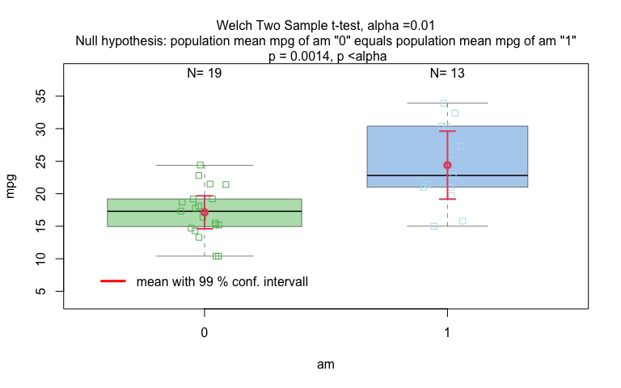

#### Wilcoxon rank sum test

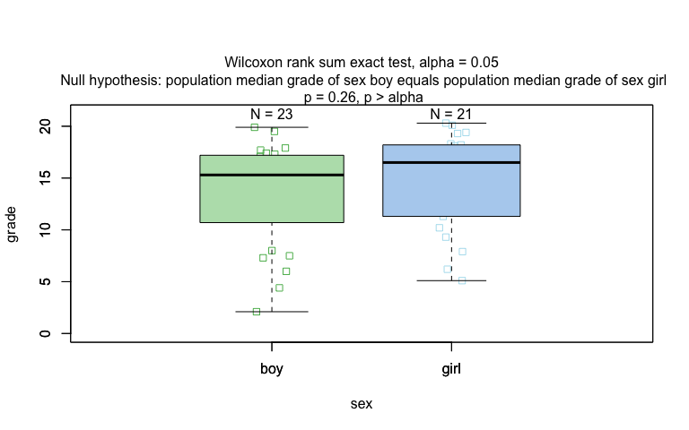

## 2.2 One-way test, ANOVA or Kruskal-Wallis test

If the feature is of `class` “`factor`” with more than two levels and the response is of `mode` “`numerical`”, `visstat()` initially attempts an analysis of variance (ANOVA). ANOVA is performed only if both of the following null hypotheses cannot be rejected at the specified `conf.level`:

1. The standardized residuals follow a normal distribution, and
2. The residuals exhibit homoscedasticity (equal variances across groups).

If only the assumption of normality is satisfied, `visstat()` applies Welch’s one-way test (`oneway.test()`). If the normality assumption is violated, a Kruskal-W allis test (`kruskal.test()`) is used instead.

These assumptions are tested internally using the `visAnovaAssumptions()` function.

### 2.2.1 Checking the ANOVA assumptions

#### Residual analysis

The `visAnovaAssumptions()` function assesses the normality of standardized residuals from the ANOVA fit using both the Shapiro-W ilk test (`shapiro.test()`) and the Anderson-Darling test (`ad.test()`). Normality is assumed if at least one of the two tests yields a $p$-value greater than $1 -$ `conf.level`.

The function generates two diagnostic plots:  
- a scatterplot of the standardized residuals against the fitted means of the linear model for each level of the feature (`varfactor`), and  
- a Q-Q plot of the standardized residuals.

#### Homoscedasticity: homogeneity of variances in each level: Bartlett test

Both `aov()` and `oneway.test()` assess whether two or more samples drawn from normal distributions have the same mean. While `aov()` assumes homogeneity of variances across groups, `oneway.test()` does not require the variances to be equal.

Homoscedasticity is assessed using Bartlett`s test (`bartlett.test()`), which tests the null hypothesis that the variances across all levels of the grouping variable are equal.

### 2.2.2 One-way test and ANOVA

Depending on the $p$-value returned by `bartlett.test()`, the corresponding test is selected and its $p$-value is displayed in the figure title:

- If the $p$-value of `bartlett.test()` is greater than $1 -$ `conf.level`, we assume homogeneity of variances across groups and report the $p$-value from the ANOVA (`aov()`).
- Otherwise, homoscedasticity cannot be assumed, and the function reports the $p$-value from Welch’s one-way test (`oneway.test()`).

#### Post-hoc analysis: Tukey’s Honestly Significant Differences (HSD) and Sidak-corrected confidence intervals

Simple pairwise comparisons of group means following an analysis of variance increase the probability of incorrectly declaring a significant difference when, in fact, there is none .

This inflation of error is quantified by the family-wise error rate, which refers to the probability of making at least one Type I error, that is, falsely rejecting the null hypothesis across all pairwise comparisons.

To control it, `visstat()` performs post-hoc analysis using Tukey’s Honestly Significant Difference (HSD) test and displays Sidak-corrected confidence intervals.

The `visstat()` function controls the probability of a Type I error by applying Tukey`s Honestly Significant Differences procedure, as implemented in `TukeyHSD()`.  
Based on the specified confidence level (`conf.level`), it constructs a set of confidence intervals for all pairwise differences between factor level means. A significant difference between two means is indicated when the corresponding confidence interval does not include zero.  
The function returns both the HSD-adjusted $p$-values and the associated confidence intervals for all pairwise comparisons.

In the graphical output for the one-way test and ANOVA, green letters displayed below each group summarize the results of the Tukey HSD post-hoc test: Two groups are considered significantly different if they are assigned different letters, indicating a Tukey HSD-adjusted $p$-value smaller than $\alpha = 1 -$ `conf.level`.

Tukey`s HSD procedure is based on pairwise comparisons of the differences between the means at each factor level and produces a set of corresponding confidence intervals. The Sidak procedure, on the other hand, addresses the problems of a type I error by lowering the acceptable probability of a type I error for all comparisons of the levels of the independent, categorical variable.

In the graphical display of One-way test and ANOVA, `visstat()` displays both the `conf.level` $\cdot\; 100 \%$-confidence intervals alongside the larger, Sidak-corrected $(1-\alpha_{Sidak})\cdot 100\;\%$-confidence intervals.

Note that the current structure of `visstat()` does not allow the study of interactions between the different levels of an independent variable.

### 2.2.3 Kruskal-Wallis test

If the $p$-value from the Shapiro-Wilk test (`shapiro.test()`) applied to the standardized residuals is smaller than the significance level $1 -$ `conf.level`, `visstat()` selects a non-parametric alternative: the Kruskal-Wallis rank sum test.

The function `kruskal.test()` tests the null hypothesis that the group medians are equal across all levels of the categorical feature.

#### Post-hoc analysis: `pairwise.wilcox.test()`

As post-hoc analysis following the Kruskal-Wallis test, `visstat()` applies the pairwise Wilcoxon rank sum test using `pairwise.wilcox.test()`, with Holm-s method as the default adjustment for multiple comparisons (Holm 1979).

If the Holm-adjusted $p$-value for a given pair of groups is smaller than the significance level $1 -$ `conf.level`, the green letters displayed below the corresponding box plots will differ. Otherwise, the groups are considered not significantly different.

Apart from the multiple comparison adjustment, the graphical representation of the Kruskal-Wallis result is similar to that used for the Wilcoxon rank sum test.

The function returns a list containing the test statistic from the Kruskal-Wallis rank sum test, along with the Holm-adjusted $p$-values for all pairwise comparisons.

### 2.2.4 Examples

#### One-way test:

The `npk` dataset reports the yield of peas (in pounds per block) from an agricultural experiment conducted on six blocks. In this experiment, the application of three different fertilisers - nitrogen (N), phosphate (P), and potassium (K) - was varied systematically. Each block received either none, one, two, or all three of the fertilisers,

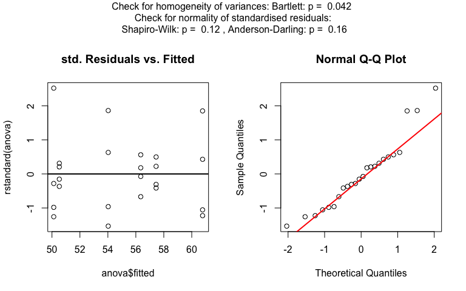

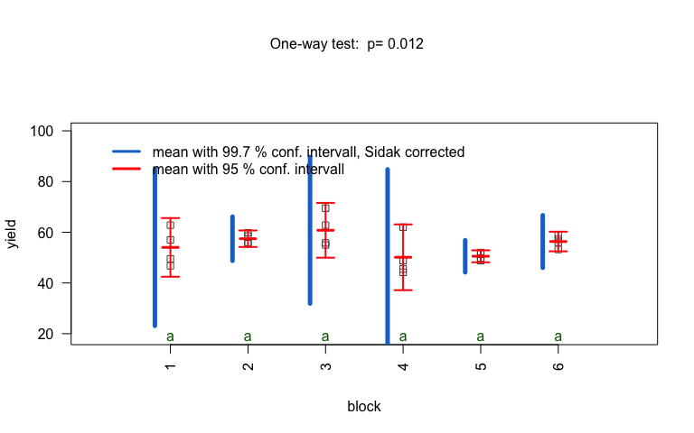

Normality of residuals is supported by graphical diagnostics (scatter plot of standardized residuals, Q-Q plot) and formal tests (Shapiro-Wilk and Anderson-Darling, both with $p > \alpha$). However, homogeneity of variances is not supported at the given confidence level ($p < \alpha$, `bartlett.test()`), so the $p$-value from the variance-robust `oneway.test()` is reported. Post-hoc analysis with `TukeyHSD()` shows no significant yield differences between blocks, as all share the same group label (e.g., all green letters).

#### ANOVA

The `InsectSprays` dataset reports insect counts from agricultural experimental units treated with six different insecticides. To stabilise the variance in counts, we apply a square root transformation to the response variable.

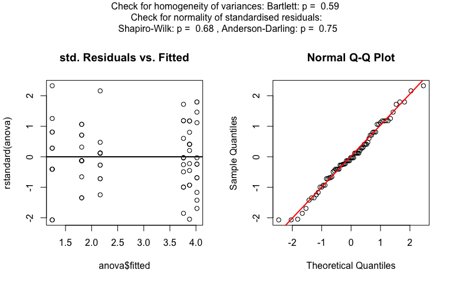

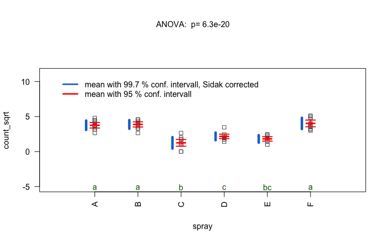

After the transformation, the homogeneity of variances can be assumed ($p> \alpha$ as calculated with the `bartlett.test()`), and the $p$-value of the `aov()` is displayed.

#### Kruskal-Wallis rank sum test

The `iris` dataset contains petal width measurements (in cm) for three different iris species.

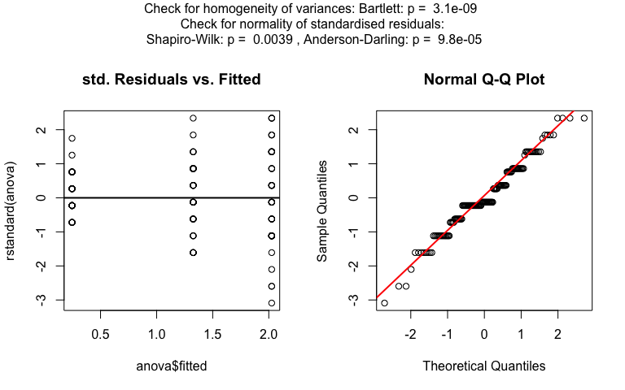

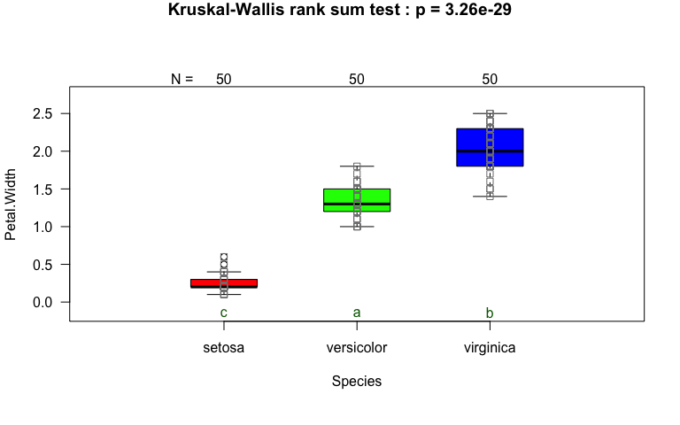

In this example, scatter plots of the standardised residuals and the Q-Q plot suggest that the residuals are not normally distributed. This is confirmed by very small $p$-values from both the Shapiro-Wilk and Anderson-Darling tests.

If both $p$-values are below the significance level $\alpha = 1 -$conf.level, `visstat()` switches to the non-parametric `kruskal.test()`. Post-hoc analysis using `pairwise.wilcox.test()` shows significant differences in petal width between all three species, as indicated by distinct group labels (all green letters differ).

# 3 Simple linear regression

If the feature `varfactor` and the response `varsample` have only one level of type `numerical` or `integer`, `visstat()` performs a simple linear regression. Note that multiple linear regression is **not** implemented, as the main focus of `visstat()` is the visualisation of statistical tests.

If the feature `varfactor` and the response `varsample` contain only one level each and both are of type `numerical` or `integer`, `visstat()` performs a simple linear regression. Note that multiple linear regression is not implemented, as the main focus of `visstat()` is on the visualisation of statistical tests.

## 3.1 Residual analysis

`visstat()` checks the normality of the standardised residuals from `lm()` both graphically and using the Shapiro-Wilk and Anderson-Darling tests. If the $p$-values for the null hypothesis of normally distributed residuals from both tests are smaller than $1 -$`conf.int`, the title of the residual plot will display the message: “Requirement of normally distributed residuals not met”.

Regardless of the result of the residual analysis, `visstat()` proceeds to perform the regression. The title of the graphical output indicates the chosen confidence level (`conf.level`), the estimated regression parameters with their confidence intervals and $p$-values, and the adjusted $R^2$. The plot displays the raw data, the fitted regression line, and both the confidence and prediction bands corresponding to the specified `conf.level`.

`visstat()` returns a list containing the regression test statistics, the $p$-values from the normality tests of the standardised residuals, and the pointwise estimates of the confidence and prediction bands.

## 3.2 Examples

### 3.2.1 Data set: `cars`

The `cars` dataset reports the speed of cars in miles per hour (`speed`) and the stopping distance in feet (`dist`).

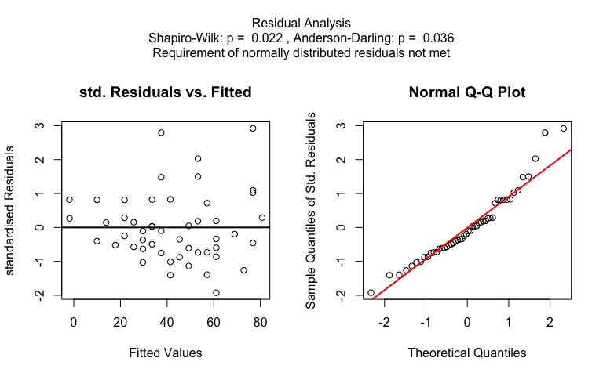

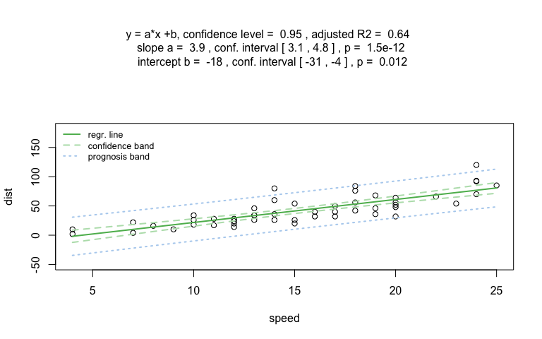

Increasing the confidence level `conf.level` from the default 0.95 to 0.99 results in wider confidence and prediction bands:

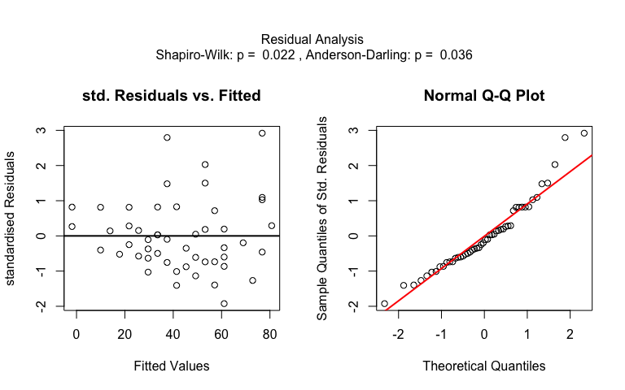

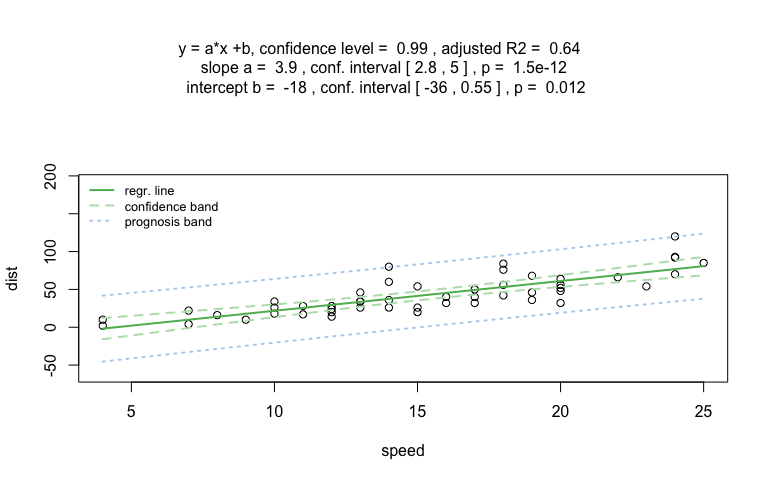

[figure not shown]

[figure not shown]

### 3.2.2 Data set: `trees`

The `trees` dataset provides measurements of the diameter (`Girth`, in inches), `Height` (in feet), and `Volume` (in cubic feet) of black cherry trees. In this example, we choose `Volume` as the response and `Girth` as the feature.

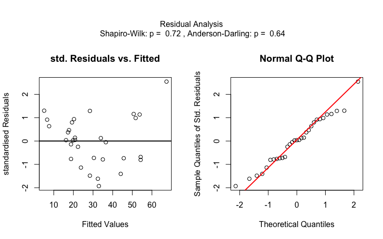

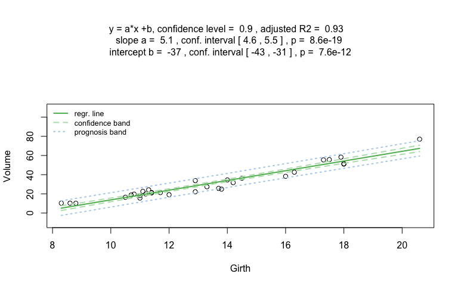

Both the graphical analysis of the standardised residuals and $p$-values greater than $1 -$conf.level in the Anderson-Darling and Shapiro-Wilk tests suggest that the assumption of normally distributed residuals is met. Furthermore, the linear regression model explains 93% of the total variance in the response variable `Volume`.

# 4 ${\chi}^2$- and Fisher Test

When both the feature `varfactor` and the response `varsample` are categorical variables (i.e., of type `factor`), `visstat()` tests the null hypothesis that the two variables are independent. Categorical data are typically represented as contingency tables, which cross-tabulate the observed frequencies for each combination of factor levels. Based on these observed frequencies, `visstat()` computes the expected frequencies under the null hypothesis of independence.

If the expected frequencies are sufficiently large - specifically, if at least 80% of the cells have expected counts greater than 5 and no expected count is zero - the function uses Pearson’s ${\chi}^2$-test (`chisq.test()`). Otherwise, it switches to Fisher’s exact test (`fisher.test()`) (Cochran 1954). For 2-by-2 contingency tables, Yate’s a continuity correction (Yates 1934) is applied to Pearson’s ${\chi}^2$-test.

For both ${\chi}^2$- and Fisher Test ‘visstat()’ displays a grouped column plot that includes the respective test’s $p$-value in the title, as well as a mosaic plot showing Pearson residuals (see the documentation of `mosaic()` in the `vcd` package for details).

All features of `visstat()` will be illustrated using the built-in data set `HairEyeColor`.

## 4.1 Data preparation: Transforming a contingency table to `data.frame`

`visstat()` requires input in the form of a column-based `data.frame`. Contingency tables can be converted to this format using the helper function `counts_to_cases()`.

`counts_to_cases()` transforms the contingency table `HairEyeColor` into `data.frame` named `HairEyeColorDataFrame`.

## 4.2 Pearson’s ${\chi}^2$-test

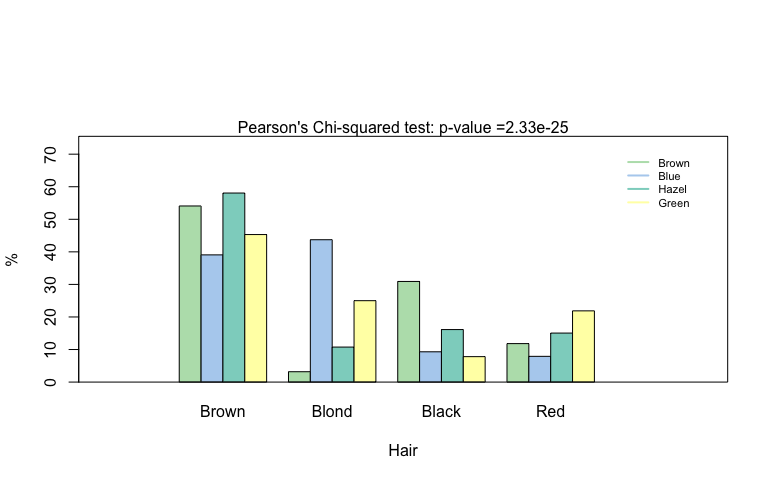

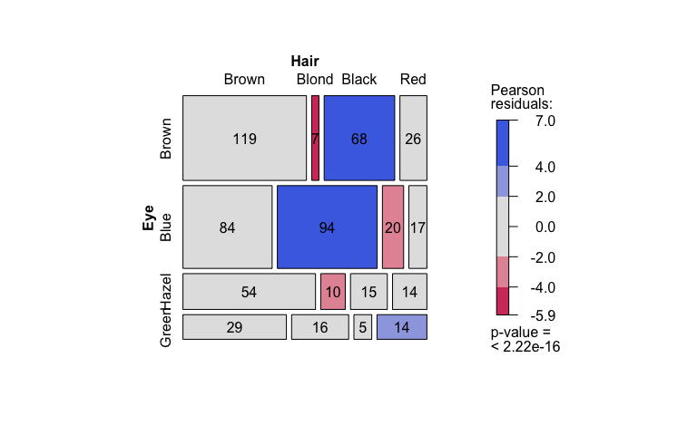

### 4.2.1 Pearson’s ${\chi}^2$-test with Yate’s continuity correction

For 2-by-2 contingency tables, `visstat()` applies Yate’s continuity correction (Yates 1934) when computing the $\chi^2$ test statistic. In the following example, we restrict the data to participants with either black or brown hair and either brown or blue eyes, resulting in a 2-by-2 contingency table.

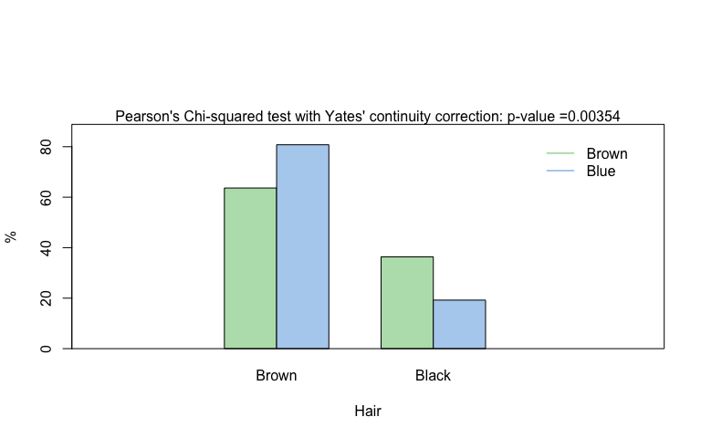

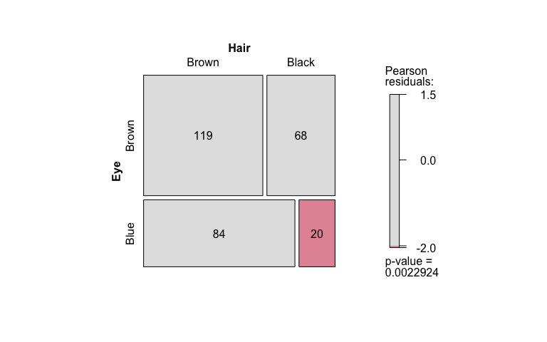

## 4.3 Fisher’s exact test and mosaic plot with Pearson residuals

Again, we extract a 2-by-2 contingency table from the full dataset, this time keeping only male participants with black or brown hair and hazel or green eyes.

Pearson’s ${\chi}^2$ test applied to this table would yield an expected frequency less than 5 in one of the four cells (25% of all cells), which violates the requirement that at least 80% of the expected frequencies must be 5 or greater (Cochran 1954).

Therefore, `visstat()` automatically selects Fisher’s exact test instead.

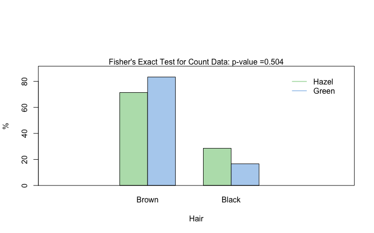

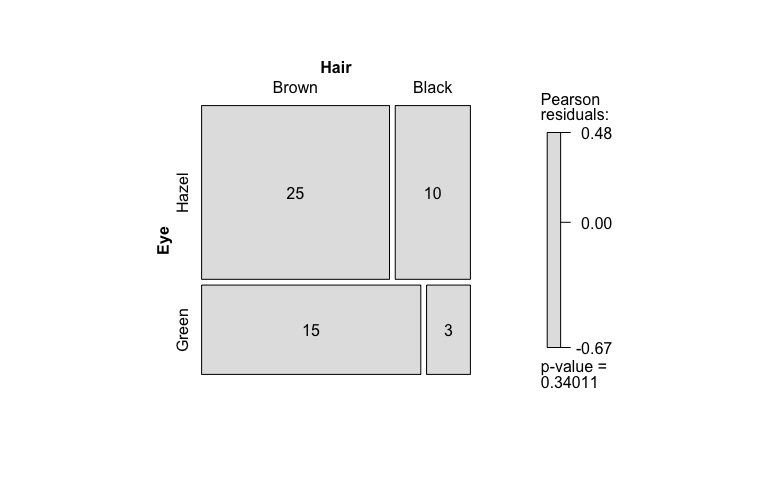

# 5 Saving the graphical output

The generated graphics can be saved in any file format supported by `Cairo()`, including “png”, “jpeg”, “pdf”, “svg”, “ps”, and “tiff”. In the following example, we store the graphics in PNG format in the `plotDirectory` `tempdir()`. The file names reflect the statistical test used and the variable names involved.

Remove the graphical output from `plotDirectory`:

```
#> [1] TRUE
#> [1] TRUE
```

# 6 Implemented tests

## 6.1 Numerical response and categorical feature

When the response is numerical and the feature is categorical, test of central tendencies are selected:

`t.test()`, `wilcox.test()`, `aov()`, `oneway.test()`,`kruskal.test()`

### 6.1.1 Normality assumption check

`shapiro.test()` and `ad.test()`

### 6.1.2 Homoscedasticity assumption check

`bartlett.test()`

### 6.1.3 Post-hoc tests

- `TukeyHSD()` (for `aov()`and `oneway.test()`)
- `pairwise.wilcox.test()` (for `kruskal.test()`)

## 6.2 Numerical response and numerical feature

When both the response and feature are numerical, a simple linear regression model is fitted:

`lm()`

## 6.3 Categorical response and categorical feature

When both variables are categorical, `visstat()` tests the null hypothesis of independence using one of the following:

- `chisq.test()` (default for larger samples)
- `fisher.test()` (used for small expected cell counts based on Cochran’s rule)

# Bibliography

Cochran, William G. and. 1954. “The combination of estimates from different experiments.” *Scandinavian Journal of Statistics* 10 (1): 101–20. https://doi.org/10.2307/3001666.

Delacre, M, D Lakens, C Leys International Review of Social, and 2017. 2017. “Why Psychologists Should by Default Use Welch’s t-test Instead of Student’s t-test.” *International Review of Social Psychology*. https://doi.org/10.5334/irsp.82.

Holm, S. 1979. “A Simple Sequentially Rejective Multiple Test Procedure.” *Scandinavian Journal of Statistics* 6: 65–70.

Lumley, Thomas, Paula Diehr, Scott Emerson, and Lu Chen. 2002. “The importance of the normality assumption in large public health data sets.” *Annual Review of Public Health* 23: 151–69. https://doi.org/10.1146/annurev.publhealth.23.100901.140546.

Moser, B K, and GR Stevens. 1992. “Homogeneity of variance in the two-sample means test.” *The American Statistician*, February, 19–21. https://doi.org/10.1080/00031305.1992.10475839.

Rasch, Dieter, Klaus D Kubinger, and Karl Moder. 2011. “The two-sample t test: pre-testing its assumptions does not pay off.” *Statistical Papers* 52 (1): 219–31. https://doi.org/10.1007/s00362-009-0224-x.

Šidák, Zbyněk. 1967. “Rectangular Confidence Regions for the Means of Multivariate Normal Distributions.” *Journal of the American Statistical Association* 62 (318): 626–33. https://doi.org/10.1080/01621459.1967.10482935.

Yates, F. 1934. “Contingency Tables Involving Small Numbers and the Χ2 Test.” *Supplement to the Journal of the Royal Statistical Society* 1 (2): 217–35. https://doi.org/10.2307/2983604.